# PEC4

Andrea C., Diana S.

2026-01-10

# Sección 1. Contexto y objetivo del estudio. Datos (1 punto)

**Debéis buscar un conjunto de datos relacionado con la Bioestadística y la Bioinformática, basándoos en los intereses profesionales o las preferencias del grupo.** **Especificad la procedencia o el origen de los datos, incluid las referencias correspondientes y justificad por qué habéis elegido estos datos, indicando qué objetivos o preguntas queréis responder.**

Los datos proceden del estudio “Exploring Relationships in Body Dimensions” publicado en el Volúmen 11, número 2 del JSE (Journal of Statistics Education), también conocido cómo el JSDSE (Journal of Statistics and Data Science Education), en 2003 por Grete Heinz y Louis Peterson. Se estudian las proporciones del cuerpo humano a partir de numerosas medidas (abdomen, extremidades, peso, altura).

Hemos escogido estos datos ya que la muestra es grande, con variables tanto numéricas como categóricas, con la posibilidad de procesar alguna variable para crear rangos y valorar otros enfoques y es un tema para el que podemos formular diversas hipótesis partiendo de diferentes perspectivas - género, edad, peso. No tiene valores nulos, lo que nos beneficia principalmente porque no perdemos datos, y además facilita el procesado de los datos para los apartados más complejos como los modelos de aprendizaje automático y la visualización con shiny.

El objetivo principal es comprobar diferencias biológicas que puedan ser explicadas según el principio de dimorfismo sexual, comparar las tendencias observadas con los patrones de acumulación de grasa asociados al sexo del individuo, qué medidas van más estrechamente relacionadas con el aumento o descenso del peso, encontrar medidas clave que permitan inducir otras a través de modelos de predicción y detectar tendencias según la edad.

# Sección 2. Prospección y preparación de los datos. (2 puntos)

## 2.1 Descripción de los datos (1 punto)

**Utilizando R, mostrad y explicad el tipo de fichero que habéis importado y las variables que lo componen. Esta descripción debe incluir (basándose en conceptos del LAB1):**

● Descripción general del conjunto de datos. ● Tipo y clasificación de las variables (numéricas, categóricas, etc.). ● Tamaño del conjunto de datos. ● Detección de valores nulos. ● Valoración del conjunto de datos (necesidad de transformaciones o presencia de inconsistencias). Debéis incluir capturas de pantalla y las instrucciones en R utilizadas para importar y mostrar los datos.

El tipo de fichero importado es un fichero de text (.txt) de formato ancho fijo (fixed-width), lo que quiere decir que cada columna contiene un número fijo de posiciones de caracteres que hemos de traducir al importar el documento. Las posiciones que usaremos están indicadas en el apéndice del paper, y a través de la función fwf_positions() designaremos los puntos de inicio, final, y las etiquetas de las columnas (medidas) para asignar a éstas de manera respectiva. Después crearemos el conjunto de datos con la función read_fwf(“pathway del archivo”, “información de lectura que hemos creado”).

Implementación de los datos para trabajar con ellos:

```r
library(readr)
col_positions <- fwf_positions(
start = c(1, 6, 11, 16, 21, 26, 31, 36, 41, 46, 52, 58, 64, 70, 76, 81, 86, 91, 96, 101, 106, 111, 116, 122, 128),
end = c(4, 9, 14, 19, 24, 29, 34, 39, 44, 50, 56, 62, 68, 74, 79, 84, 89, 94, 99, 104, 109, 114, 120, 126, 128),
col_names = c("biacromial", "biiliac", "bitrochanteric", "chest_depth", "chest_diameter",
"elbow_diameter", "wrist_diameter", "knee_diameter", "ankle_diameter",
"shoulder_girth", "chest_girth", "waist_girth", "navel_girth", "hip_girth",
"thigh_girth", "bicep_girth", "forearm_girth", "knee_girth", "calf_girth",
"ankle_girth", "wrist_girth", "age", "weight", "height", "gender")
)
BODYDATA <- read_fwf("datos/body.dat.txt", col_positions)
```

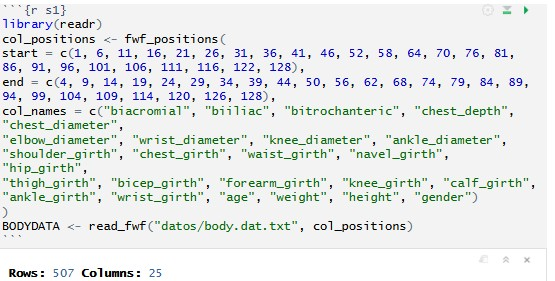

[figure not shown]

Como podemos ver este método ya nos da las dimensiones de los datos (507 rows, 25 columnas.) Si comprobamos la estructura con str(BODYDATA), encontramos que al importar, todas son numéricas.

```r
str(BODYDATA) #Estructura de los datos
```

```
## spc_tbl_ [507 × 25] (S3: spec_tbl_df/tbl_df/tbl/data.frame)
##  $ biacromial    : num [1:507] 42.9 43.7 40.1 44.3 42.5 43.3 43.5 44.4 43.5 42 ...
##  $ biiliac       : num [1:507] 26 28.5 28.2 29.9 29.9 27 30 29.8 26.5 28 ...
##  $ bitrochanteric: num [1:507] 31.5 33.5 33.3 34 34 31.5 34 33.2 32.1 34 ...
##  $ chest_depth   : num [1:507] 17.7 16.9 20.9 18.4 21.5 19.6 21.9 21.8 15.5 22.5 ...
##  $ chest_diameter: num [1:507] 28 30.8 31.7 28.2 29.4 31.3 31.7 28.8 27.5 28 ...
##  $ elbow_diameter: num [1:507] 13.1 14 13.9 13.9 15.2 14 16.1 15.1 14.1 15.6 ...
##  $ wrist_diameter: num [1:507] 10.4 11.8 10.9 11.2 11.6 11.5 12.5 11.9 11.2 12 ...
##  $ knee_diameter : num [1:507] 18.8 20.6 19.7 20.9 20.7 18.8 20.8 21 18.9 21.1 ...
##  $ ankle_diameter: num [1:507] 14.1 15.1 14.1 15 14.9 13.9 15.6 14.6 13.2 15 ...
##  $ shoulder_girth: num [1:507] 106 110 115 104 108 ...
##  $ chest_girth   : num [1:507] 89.5 97 97.5 97 97.5 ...
##  $ waist_girth   : num [1:507] 71.5 79 83.2 77.8 80 82.5 82 76.8 68.5 77.5 ...
##  $ navel_girth   : num [1:507] 74.5 86.5 82.9 78.8 82.5 80.1 84 80.5 69 81.5 ...
##  $ hip_girth     : num [1:507] 93.5 94.8 95 94 98.5 95.3 101 98 89.5 99.8 ...
##  $ thigh_girth   : num [1:507] 51.5 51.5 57.3 53 55.4 57.5 60.9 56 50 59.8 ...
##  $ bicep_girth   : num [1:507] 32.5 34.4 33.4 31 32 33 42.4 34.1 33 36.5 ...
##  $ forearm_girth : num [1:507] 26 28 28.8 26.2 28.4 28 32.3 28 26 29.2 ...
##  $ knee_girth    : num [1:507] 34.5 36.5 37 37 37.7 36.6 40.1 39.2 35.5 38.3 ...
##  $ calf_girth    : num [1:507] 36.5 37.5 37.3 34.8 38.6 36.1 40.3 36.7 35 38.6 ...
##  $ ankle_girth   : num [1:507] 23.5 24.5 21.9 23 24.4 23.5 23.6 22.5 22 22.2 ...
##  $ wrist_girth   : num [1:507] 16.5 17 16.9 16.6 18 16.9 18.8 18 16.5 16.9 ...
##  $ age           : num [1:507] 21 23 28 23 22 21 26 27 23 21 ...
##  $ weight        : num [1:507] 65.6 71.8 80.7 72.6 78.8 74.8 86.4 78.4 62 81.6 ...
##  $ height        : num [1:507] 174 175 194 186 187 ...
##  $ gender        : num [1:507] 1 1 1 1 1 1 1 1 1 1 ...
##  - attr(*, "spec")=
##   .. cols(
##   ..   biacromial = col_double(),
##   ..   biiliac = col_double(),
##   ..   bitrochanteric = col_double(),
##   ..   chest_depth = col_double(),
##   ..   chest_diameter = col_double(),
##   ..   elbow_diameter = col_double(),
##   ..   wrist_diameter = col_double(),
##   ..   knee_diameter = col_double(),
##   ..   ankle_diameter = col_double(),
##   ..   shoulder_girth = col_double(),
##   ..   chest_girth = col_double(),
##   ..   waist_girth = col_double(),
##   ..   navel_girth = col_double(),
##   ..   hip_girth = col_double(),
##   ..   thigh_girth = col_double(),
##   ..   bicep_girth = col_double(),
##   ..   forearm_girth = col_double(),
##   ..   knee_girth = col_double(),
##   ..   calf_girth = col_double(),
##   ..   ankle_girth = col_double(),
##   ..   wrist_girth = col_double(),
##   ..   age = col_double(),
##   ..   weight = col_double(),
##   ..   height = col_double(),
##   ..   gender = col_double()
##   .. )
##  - attr(*, "problems")=<externalptr>
```

Este conjunto de datos contiene una serie de 25 medidas antropométricas (25 variables) en centímetros de un total de 507 individuos. Estas medidas son planas (entre crestas como las acromiales e ilíacas), de profundidad y diámetro (codo, muñeca, rodilla y tobillo) y de circunferencia (hombro, pecho, cintura, abdomen, muslo, biceps, pantorrilla), además de altura, peso, edad y género. Todas las variables aparecen como numéricas. Las medidas en centímetros, el peso y la altura son variables contínuas, la edad la consideraríamos variable numérica discreta y el género a pesar de estar etiquetado con sistema numérico, es categórico con dos niveles (0 - Mujer, 1 - Hombre).

Comprobamos si hay valores nulos asignando la función de contabilizarlos a una variable, y mostramos la variable. En caso de que hubiera, utilizaríamos la función na.omit(BODYDATA), pero no hay valores nulos así que no hace falta.

```r
contNA <- sum(is.na(BODYDATA))
contNA
```

```
## [1] 0
```

Como tal no hay necesidad previa al estudio de transformar los datos, solo de tener en cuenta que la variable género está representada numéricamente (0 = mujer, 1 = hombre).

## 2.2 Preguntas “objetivo” (1 punto)

**Plantead un mínimo de cuatro preguntas objetivo que den una idea de la información contenida en el conjunto de datos. El objetivo es obtener información a partir de determinados criterios, según variables o rangos de valores. Podéis basaros en el tipo de consultas realizadas en la PEC1 y utilizar, en alguno de los casos, la definición de funciones (tal como se trabaja en el LAB3).**

- ¿Qué tan evidente es el dimorfismo sexual en los humanos, a nivel biológico?
- ¿Qué medidas corporales están más estrechamente relacionadas con el aumento de peso?
- ¿Se acumula la grasa con algún patrón específico según el sexo del individuo? Es decir, ¿varían igual las medidas corporales en aumentar el peso entre hombres y mujeres, o detectamos algún patrón?
- ¿Son las medidas más alejadas del *core* las menos adecuadas para realizar predicciones biológicas? - ¿Se desechan medidas de muñeca, codo, tobillo y rodilla en modelos de regresión múltiple?

# Sección 3. Análisis exploratorio de los datos (2,5 puntos)

## 3.1 Análisis descriptivo y gráfico (1 punto)

**Realizad un análisis descriptivo de los datos (basado en conceptos del LAB2). Este estudio debe incluir un resumen paramétrico de los datos y diversas representaciones gráficas basadas en criterios determinados según los tipos de variables y el objetivo del estudio. El tipo de gráficos y los criterios quedan a vuestra elección.**

*Resumen paramétrico global* Podemos usar la función describe() del paquete psych para obtener 12 parámetros estadísticos de interés, entre ellos la media, la desviación estandar, mediana, cuartiles, valores máximos y mínimos que nos describen para cada variable y nos dan información sobre las magnitudes. También tenemos skew y kurtosis con los que podemos estimar la normalidad de la distribución de los datos para cada una. Además podemos volver a comprobar que hay 25 variables y 507 observaciones de cada una, lo que corresponde a 0 valores nulos para este dataset (12.675 datos en total).

```r
if (!require(psych)) {
  install.packages("psych")
  library(psych)
}
describe(BODYDATA)
```

```
##                vars   n   mean    sd median trimmed   mad   min   max range
## biacromial        1 507  38.81  3.06   38.7   38.74  3.71  32.4  47.4  15.0
## biiliac           2 507  27.83  2.21   28.0   27.89  2.08  18.7  34.7  16.0
## bitrochanteric    3 507  31.98  2.03   32.0   32.00  2.08  24.7  38.0  13.3
## chest_depth       4 507  19.23  2.52   19.0   19.09  2.52  14.3  27.5  13.2
## chest_diameter    5 507  27.97  2.74   27.8   27.89  3.26  22.2  35.6  13.4
## elbow_diameter    6 507  13.39  1.35   13.3   13.38  1.48   9.9  16.7   6.8
## wrist_diameter    7 507  10.54  0.94   10.5   10.54  1.04   8.1  13.3   5.2
## knee_diameter     8 507  18.81  1.35   18.7   18.77  1.33  15.7  24.3   8.6
## ankle_diameter    9 507  13.86  1.25   13.8   13.85  1.33   9.9  17.2   7.3
## shoulder_girth   10 507 108.20 10.37  108.2  107.99 12.90  85.9 134.8  48.9
## chest_girth      11 507  93.33 10.03   91.6   93.04 11.42  72.6 118.7  46.1
## waist_girth      12 507  76.98 11.01   75.8   76.27 12.01  57.9 113.2  55.3
## navel_girth      13 507  85.65  9.42   84.6   85.21  9.34  64.0 121.1  57.1
## hip_girth        14 507  96.68  6.68   96.0   96.41  6.38  78.8 128.3  49.5
## thigh_girth      15 507  56.86  4.46   56.3   56.56  4.15  46.3  75.7  29.4
## bicep_girth      16 507  31.17  4.25   31.0   31.06  5.04  22.4  42.4  20.0
## forearm_girth    17 507  25.94  2.83   25.8   25.88  3.71  19.6  32.5  12.9
## knee_girth       18 507  36.20  2.62   36.0   36.12  2.52  29.0  49.0  20.0
## calf_girth       19 507  36.08  2.85   36.0   36.02  2.82  28.4  47.7  19.3
## ankle_girth      20 507  22.16  1.86   22.0   22.08  1.78  16.4  29.3  12.9
## wrist_girth      21 507  16.10  1.38   16.1   16.07  1.63  13.0  19.6   6.6
## age              22 507  30.18  9.61   27.0   28.99  7.41  18.0  67.0  49.0
## weight           23 507  69.15 13.35   68.2   68.58 14.83  42.0 116.4  74.4
## height           24 507 171.14  9.41  170.3  170.93 10.67 147.2 198.1  50.9
## gender           25 507   0.49  0.50    0.0    0.48  0.00   0.0   1.0   1.0
##                 skew kurtosis   se
## biacromial      0.16    -0.84 0.14
## biiliac        -0.42     1.07 0.10
## bitrochanteric -0.09     0.02 0.09
## chest_depth     0.49    -0.14 0.11
## chest_diameter  0.26    -0.74 0.12
## elbow_diameter  0.05    -0.74 0.06
## wrist_diameter  0.05    -0.49 0.04
## knee_diameter   0.34     0.07 0.06
## ankle_diameter  0.07    -0.38 0.06
## shoulder_girth  0.14    -0.90 0.46
## chest_girth     0.24    -0.89 0.45
## waist_girth     0.54    -0.23 0.49
## navel_girth     0.45     0.13 0.42
## hip_girth       0.50     0.76 0.30
## thigh_girth     0.69     0.72 0.20
## bicep_girth     0.22    -0.83 0.19
## forearm_girth   0.15    -0.98 0.13
## knee_girth      0.47     1.00 0.12
## calf_girth      0.28     0.29 0.13
## ankle_girth     0.40     0.36 0.08
## wrist_girth     0.15    -0.73 0.06
## age             1.13     0.94 0.43
## weight          0.40    -0.36 0.59
## height          0.15    -0.46 0.42
## gender          0.05    -2.00 0.02
```

Aquí podemos observar como difieren medidas planas de sus correspondientes medidas de perímetro, como es el caso de los pares “biacromial” - “shoulder_girth” y “bitrochanteric” - “hip_girth”. La media de la distancia entre las crestas acromiales es de 38.81 centímetros (un valor muy cercano a la mediana/Q2) y con una desviación estándar de aproximadamente 3 centímetros mientras que el correspondiente perímetro de hombros mide el volumen de esta zona y tiene una media de 108.20 y una desviación de 10.37 centímetros.

A simple vista puede parecer que el estadístico de media y desviación estandar para el género no tiene sentido pero que nos dé una media de 0.49+-0.50 es un indicador muy bueno de que el estudio es equitativo, es decir, la mitad o casi la mitad de la muestra es hombre (1), la otra mitad mujer (0).

El siguiente estudio descriptivo se hará sobre las variables “waist_girth”, “hip_girth”, “biacromial” y “weight”.

#### HISTOGRAMA. Waist_girth.

Observaremos la distribución del perímetro de cintura a través de la muestra con un histograma.

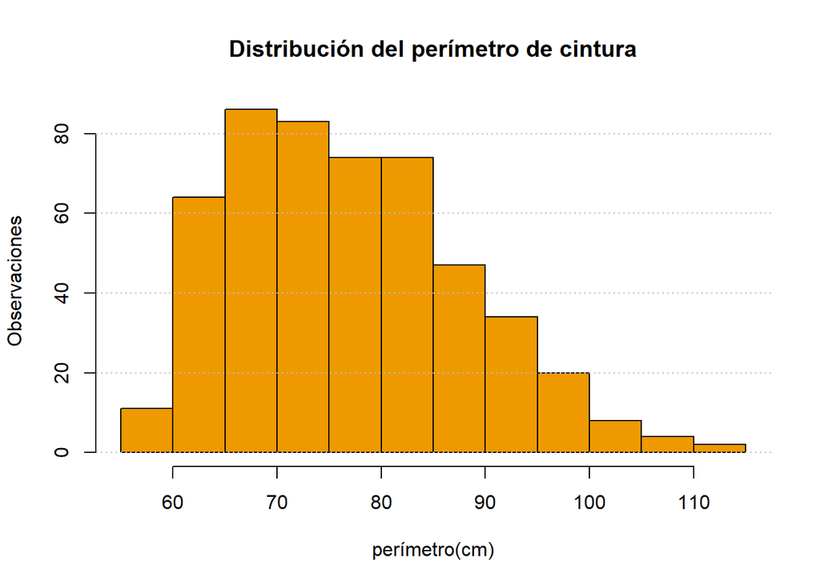

```r
hist(BODYDATA$waist_girth,
     main = "Distribución del perímetro de cintura",
     xlab = "perímetro(cm)",
     ylab = "Observaciones",
     col = "orange2")
abline(h = axTicks(2), col = "gray", lty = "dotted")
```

#### BOXPLOT. Hip_girth en función de género.

Observaremos la distribución del perímetro de cadera en función del género. Esperamos encontrar dimorfismo sexual. Podríamos usar biiliac, pero la acumulación de grasa en esta zona también es un patrón biológico, así que consideramos correcto asumir hip_girth en lugar de biiliac.

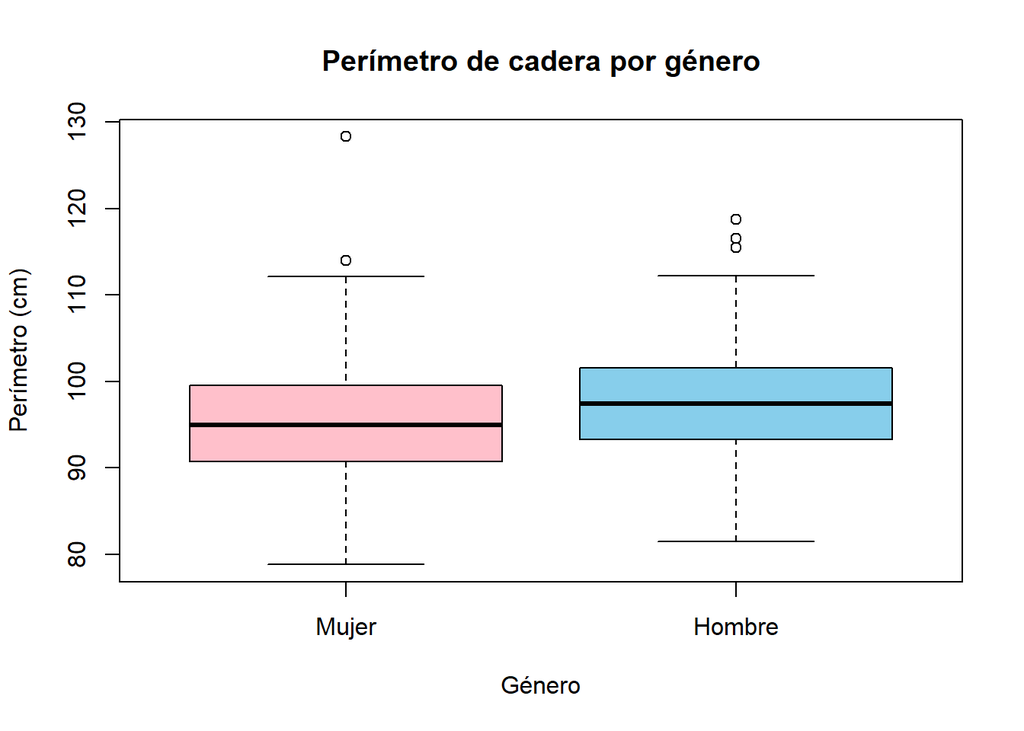

```r
boxplot(hip_girth~gender, data = BODYDATA,
        main = "Perímetro de cadera por género",
        xlab = "Género",
        ylab = "Perímetro (cm)",
        names = c("Mujer", "Hombre"),
        col = c("pink", "skyblue"))
```

Nos encontramos que al asumir a ciegas y sin tener en cuenta la talla de los individuos, los hombres presentan perímetros mayores de cadera. Como accesorio para el contexto, añadimos un scatterplot del peso en función de la altura, coloreado según el género.

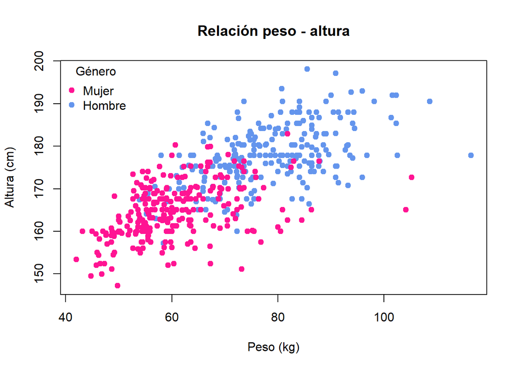

```r
#Si es 1 (HOMBRE) asocia azul, si no, rosa:
colores <- ifelse(BODYDATA$gender == "1", "cornflowerblue", "deeppink")
#Plot
plot(BODYDATA$weight, BODYDATA$height,
     xlab = "Peso (kg)",
     ylab = "Altura (cm)",
     main = "Relación peso - altura",
     pch = 19,
     col = colores)
legend("topleft",
       legend = c("Mujer", "Hombre"),
       col = c("deeppink", "cornflowerblue"),
       pch = 19,
       title = "Género",
       bty = "n")
```

Y con esto podríamos teorizar que esta diferencia se vea influenciada por la diferencia de tamaños entre los dos géneros. El camino correcto para comprobar esta hipótesis sería hacer un estudio de proporciones con respecto a la cadera y ver si las mujeres presentan una tendencia a mayores caderas que los hombres.

#### BOXPLOT 2: Distancia biacromial en función de género.

O en otras palabras, la distancia entre las dos crestas de los hombros, es la medida más médica para el marco óseo en lugar de shoulder_girth. Esperamos encontrar dimorfismo sexual, también.

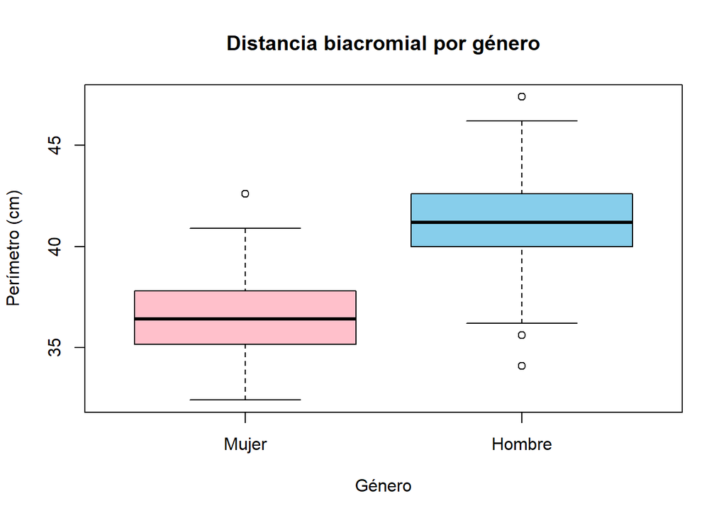

```r
boxplot(biacromial ~ gender, data = BODYDATA,
        main = "Distancia biacromial por género",
        xlab = "Género",
        ylab  = "Perímetro (cm)",
        names = c("Mujer", "Hombre"),
        col = c("pink", "skyblue"))
```

Comprobamos que existe una diferencia grande entre los marcos óseos de hombres y mujeres para la alta espalda, la media de los hombres estando por encima de los 40 centímetros, y la media de las mujeres por debajo; valores atípicosde mujeres extendiéndose hasta por encima de los 40 donde se encuentran aún valores normales para hombres.

#### SCATTERPLOT. Waist_girth con hip_girth.

Esto podría mostrarnos asociación morfológica entre ambas y en cómo puede sesgar nuestra asociación de la hip_girth a un género en concreto si lo coloreamos por género.

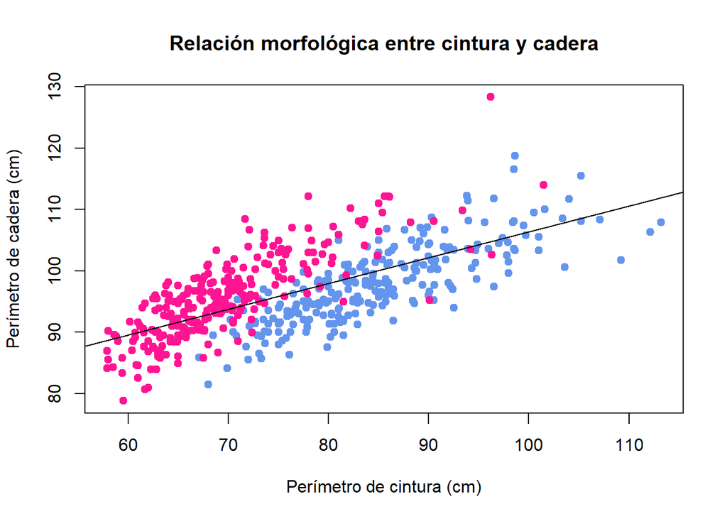

```r
colores2 <- ifelse(BODYDATA$gender == 1, "cornflowerblue", "deeppink")
plot(BODYDATA$waist_girth, BODYDATA$hip_girth,
     xlab = "Perímetro de cintura (cm)",
     ylab = "Perímetro de cadera (cm)",
     main = "Relación morfológica entre cintura y cadera",
     pch = 19,
     col = colores2)
abline(lm(hip_girth ~ waist_girth, data = BODYDATA), col = "black")
```

Vemos que en esta muestra hay una cierta agrupación de observaciones femeninas con altos perímetros de cadera a menores perímetros de cintura, situándose por encima de hombres con el mismo perímetro de cintura pero menores de cadera, lo que indicaría que a mismos perímetros de cintura -**70, 80 centímetros**- las mujeres presentan mayor perímetro de cadera que los hombres, lo que podría responder a la acumulación biológica de grasa en esas zonas, o a que parten de una base ósea mayor (distancia bitrocantérica).

## 3.2 EJERCICIOS DE INFERENCIA Y SIMULACIÓN (1.5 puntos)

**a) Basándoos en los conceptos trabajados en el LAB3, definid una función en R que realice algún tipo de cálculo de interés en el contexto del conjunto de datos.**

Un parámetro de interés es el IMC; aunque con ello surgen una serie de dudas que comentaremos más adelante.

Para el contexto de estos datos, aunque no hay NA ni valores 0, agregamos la comprobación básica. Tras eso y teniendo en cuenta que la medida de la altura ya está en centímetros, describimos la función de la siguiente manera:

```r
#Función ÍNDICE MASA CORPORAL

calcular_IMC <- function(peso, altura){
  #Comprobación básica
  if (any(is.na(peso)) || any(altura <= 0)){
    stop("Se encuentran valores NA en peso o altura.")
  }
  if (any(peso <=0) || any(altura <= 0)){
    stop("Peso y altura deben ser mayores que 0.")
  }
  #Conversión cm a metros
  altura_m <- altura/100

  #CÁLCULO
  IMC <- peso / (altura_m^2)
}
BODYDATA$IMC <- calcular_IMC(BODYDATA$weight, BODYDATA$height)
summary(BODYDATA$IMC)
```

```
##    Min. 1st Qu.  Median    Mean 3rd Qu.    Max.
##   16.88   20.96   23.16   23.46   25.47   38.19
```

El resumen del IMC muestra una media de 23.46 y una mediana ligeramente inferior (23.16), lo que indica una distribución con ligera asimetría positiva. El primer y tercer cuartil (20.96 y 25.47) sitúan a la mayor parte de la muestra en valores considerados normales según clasificaciones estándar, aunque aproximadamente un 25% de los individuos se sitúa en valores compatibles con sobrepeso (IMC ≥ 25).

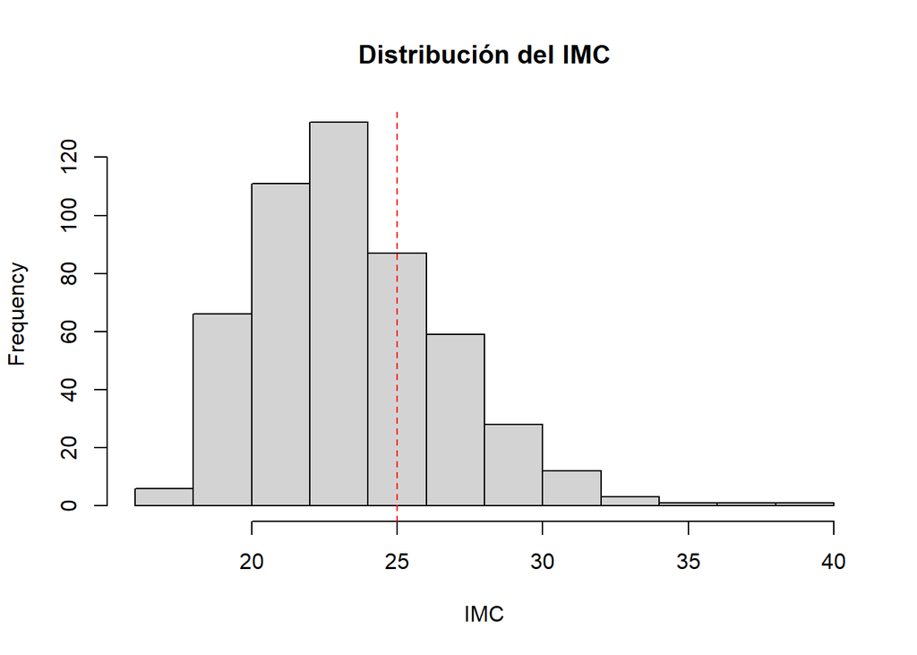

```r
hist(BODYDATA$IMC,
     main = "Distribución del IMC",
     xlab = "IMC",
     col = "lightgray")
abline(v = 25, col = "red", lty = 2)
```

La línea discontínua marca el umbral clásico del sobrepeso

**b) Basándoos en los conceptos del LAB4 y la PEC2, plantead un mínimo de tres enunciados que respondan a una cuestión de probabilidad.**

##### 1. ¿Cuál es la probabilidad de que un individuo del conjunto de datos tenga un IMC superior a la media?

Identificamos la media del IM de manera matemática por precisión, aunque tenemos por el summary del apartado anterior que ronda (23.46) y calculamos la proporción de datos por encima de esta media (IMC > media / total = media), correspondiendo al cálculo de la probabilidad empírica. Lo multiplicamos por 100 y redondeamos a dos decimales para obtener un porcentaje regular y obtenemos que:

```r
media_IMC <- mean(BODYDATA$IMC)
p1 <- mean(BODYDATA$IMC > media_IMC)
round((p1*100), digits = 2)
```

```
## [1] 44.58
```

La probabilidad de que un individuo observado presente un IMC superior a la media es del 44.58%.

##### 2. Para estudios de sobrepeso, ¿Cuál es la probabilidad de que un hombre presente un IMC superior a 25? ¿Y una mujer?

```r
p2_hombres <- mean(BODYDATA$IMC[BODYDATA$gender == 1] > 25)

p2_mujeres <- mean(BODYDATA$IMC[BODYDATA$gender == 0] > 25)

cat(
  "Probabilidad de IMC superior a 25:\n",
  "Hombres:", round((p2_hombres*100), digits = 2), "%\n",
  "Mujeres:", round((p2_mujeres*100), digits = 2), "%\n"
)
```

```
## Probabilidad de IMC superior a 25:
##  Hombres: 42.51 %
##  Mujeres: 17.31 %
```

En hombres es del 42.51%, en mujeres del 17.31%

Para añadir robustez, podemos calcular un intervalo de confianza. Partiendo de un modelo binomial y sabiendo que las observaciones son independientes y la probabilidad en un inicio no está condicionada, podemos hacerlo con la función prop.test() o test de Wilson.

```r
#HOMBRES
IMCH <- BODYDATA$IMC[BODYDATA$gender == 1] #Vector filtrado IMC hombres
NH <- length(IMCH)   #tamaño muestral
XH <- sum(IMCH > 25) #cuántos hombres con imc > 25

hombres95 <- prop.test(XH, NH, conf.level = 0.95)$conf.int #Devuelve el intervalo
#PROP. MUESTRAL
PMhombres <- XH/NH

#MUJERES
IMCM <- BODYDATA$IMC[BODYDATA$gender == 0] #Vector filtrado IMC mujeres
NM <- length(IMCM)   #tamaño muestral
XM <- sum(IMCM > 25) #cuántas mujeres con imc > 25

mujeres95 <- prop.test(XM, NM, conf.level = 0.95)$conf.int #Devuelve el intervalo
#PROP. MUESTRAL
PMmujeres <- XM/NM

#Respuesta
intervalos95 <- sprintf(
  paste(
    "Probabilidad de presentar un IMC superior a 25:",
    "\nHombres: %1.f%% (IC95%%: %.1f-%.1f%%)",
    "\nMujeres: %1.f%% (IC95%%: %.1f-%.1f%%)"
  ),
  PMhombres * 100, hombres95[1] * 100, hombres95[2] * 100,
  PMmujeres * 100, mujeres95[1] * 100, mujeres95[2] * 100
)

cat(intervalos95)
```

```
## Probabilidad de presentar un IMC superior a 25:
## Hombres: 43% (IC95%: 36.3-48.9%)
## Mujeres: 17% (IC95%: 13.0-22.6%)
```

Como podemos ver con el estudio de la muestra, el 43% de los hombres y el 17% de las mujeres presentan un IMC superior a 25. Bajo el modelo binomial considerado, la probabilidad poblacional de presentar un IMC mayor a 25 se situaría entonces entre el 36.3 - 48.9% en hombres y 13.0 - 22.6% en mujeres con un 95% de confianza.

Aunque es importante apuntar que tener un IMC alto no equivale necesariamente a sobrepeso, dado que cuando tratamos el peso del individuo no estamos distinguiendo entre masa muscular o grasa, por lo que no podemos discriminar entre personas con sobrepeso real o de elevada masa muscular; lo que sí podemos afirmar es que existe IMC más alto en hombres que en mujeres y que usamos el IMC como clasificación antropométrica y no diagnóstica.

Medidas como plicometrías o bioimpedancias (Básculas que miden el porcentaje de grasa corporal) contextualizarían este marco de estudio, o en su falta, hacer un estudio de correlación entre el IMC y la circunferencia de cintura, siendo este último un indicador de la grasa abdominal.

##### 3. ¿Cuál es la probabilidad de que un hombre mida más de 185 cm, asumiendo que la altura sigue aproximadamente una distribución normal?

Aproximamos a la normal a partir de la estadística descriptiva del apartado 3.1 donde obtenemos que la media es de 171.1 cm (recortada 170.93 cm) y la mediana 170.3, lo que indica una simetría alrededor de la media. La desviación estándar de 9.41 cm y la desviación absoluta mediana de 10.67 cm muestran una dispersión moderada con un rango que va desde los 147.2 a los 198.1 centímetros de altura. La distribución de los datos presenta una asimetría leve (skew de 0.15) y un aplanamiento de la curva respecto a la normal existente pero moderado (kurtosis -0.46), lo que respalda la simetría de la curva y sus colas.

```r
alturahombres <- BODYDATA$height[BODYDATA$gender == 1] #Filtramos hombres
muhombres <- mean(alturahombres)
sdhombres <- sd(alturahombres)

#Calculo probabilidad teorica -> P(X<185) y lo restamos a 1
pteorica <- 1 - pnorm(185, mean = muhombres, sd = sdhombres)
probteorica <- pteorica * 100

#Calculo probabilidad observada (media alturas > 185)
pobs <- mean(alturahombres > 185)
pobservada <- pobs * 100

resultadonormal <- sprintf(
  "La probabilidad teórica es de %1.f%%, y la probabilidad observada de %.1f%%",
  probteorica,
  pobservada
)
cat(resultadonormal)
```

```
## La probabilidad teórica es de 16%, y la probabilidad observada de 17.0%
```

Obtenemos bajo los supuestos de normalidad que la probabilidad teórica de que un hombre mida más de 1.85m es de 16%. En el estudio, se da una probabilidad empírica del 17%. Es una diferencia de 1 punto lo que nos indica coherencia y buena aproximación.

**c) Incluid un mínimo de un enunciado que corresponda a un breve modelo de simulación. Si vuestro conjunto de datos no facilita este tipo de enunciados, podéis generar una o varias distribuciones basándoos en parámetros determinados definidos por vosotros, afines al contexto del estudio.**

Podemos utilizar un modelo de regresión lineal múltiple para obtener coeficientes de relación entre las medidas que consideramos más significativas (girth de waist, chest y hip) y el peso, y luego utilizarlos en la simulación normal para el peso. Para encontrar la variabilidad real (desviación estandar) para la simulación, extraemos los residuos del mismo modelo.

```r
#Preparamos
set.seed(777)
n <- 2000

#Valores simulados para cada variable
waist <- rnorm(n, mean(BODYDATA$waist_girth), sd(BODYDATA$waist_girth))
chest <- rnorm(n, mean(BODYDATA$chest_girth), sd(BODYDATA$chest_girth))
hip <- rnorm(n, mean(BODYDATA$hip_girth), sd(BODYDATA$hip_girth))

#Regresión múltiple (REAL)
rlmult <- lm(weight ~ waist_girth + chest_girth + hip_girth, data = BODYDATA)

#Coeficientes
coef_mult <- coef(rlmult)

#Desviación estandar del modelo
residusmult <- residuals(rlmult)
sdmult <- sd(residusmult)

#Simulación (contribución de cada factor al weight)
weightSIM <- coef_mult["(Intercept)"] +
  coef_mult["waist_girth"]*waist +
  coef_mult["chest_girth"]*chest +
  coef_mult["hip_girth"]*hip +
  rnorm(n, 0, sdmult)

summary(weightSIM)
```

```
##    Min. 1st Qu.  Median    Mean 3rd Qu.    Max.
##   35.78   62.84   68.85   68.96   75.00  110.70
```

Vamos a hacer una comparativa visual entre los datos reales y la simulación.

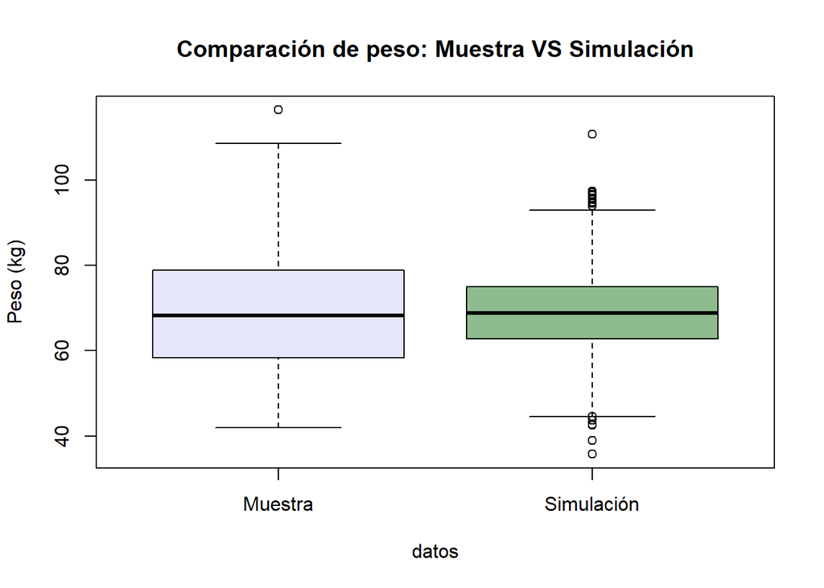

```r
simulacionplot <- data.frame(
  weight = c(BODYDATA$weight, weightSIM),
  datos = rep(c("Muestra", "Simulación"), c(nrow(BODYDATA), length(weightSIM)))
)
boxplot(weight ~ datos, data = simulacionplot,
        main = "Comparación de peso: Muestra VS Simulación",
        ylab = "Peso (kg)",
        col = c("lavender", "darkseagreen"))
```

Esta diferencia que vemos en la dispersión viene principalmente justificada porque la simulación es más grande que la propia muestra, hemos forzado una distribución completamente normal de los datos y centrada en la media, haciendo que los datos simulados se presenten de forma más simetrica y concentrada que la real.

## Sección 4. Modelos de aprendizaje automático (2.5 puntos)

**Basándoos en los conceptos trabajados en el LAB5 y a partir de vuestro conjunto de datos y de los objetivos del estudio, evaluad qué tipo de modelos conviene realizar aprendizaje supervisado o no supervisado.** ● **Justificad vuestra elección.** ● **Mostrad el detalle del estudio realizado.** ● **Incluid las representaciones gráficas correspondientes (por ejemplo, clústeres, si procede).**

Con el tipo de datos que tenemos, creemos que conviene hacer un modelo de aprendizaje automático no supervisado: tenemos muchas variables a través de las cuales se pueden iniciar varias líneas de estudio y escoger una nos hace dejar atrás muchas otras opciones válidas.

Explorar agrupamientos con las variables que tenemos a mano nos hace considerar el conjunto entero de datos para encontrar la mejor combinación de parámetros para hacer predicciones sobre perfiles morfológicos.

Partiendo de aquí, podemos utilizar un algoritmo k-means para dividir la muestra en clusters según perfiles corporales, usando medidas representativas tanto del marco óseo como del patrón de acumulación de grasa (girth) para ello, y compararlo con algún gráfico descriptivo realizado en la Sección 3.1 para detectar algún patrón. También podríamos servirnos del aprendizaje supervisado para testar la pregunta número 4 propuesta al inicio de la PAC, usando una stepAIC para detectar qué medidas son las que aportan menos información al modelo.

##### k-means. Aprendizaje no supervisado.

Primero empezaremos con el k-means, y como paso previo al algoritmo haremos elbow-method a través del decrecimiento de la suma de cuadrados intra-cluster (WSS) para determinar una k adecuada, que es el punto en el que la pendiente de reducción del WSS cambia, creando un codo en la gráfica.

Usaremos waist_girth, chest_girth, hip_girth, shoulder_girth y thigh_girth por los motivos expresados anteriormente.

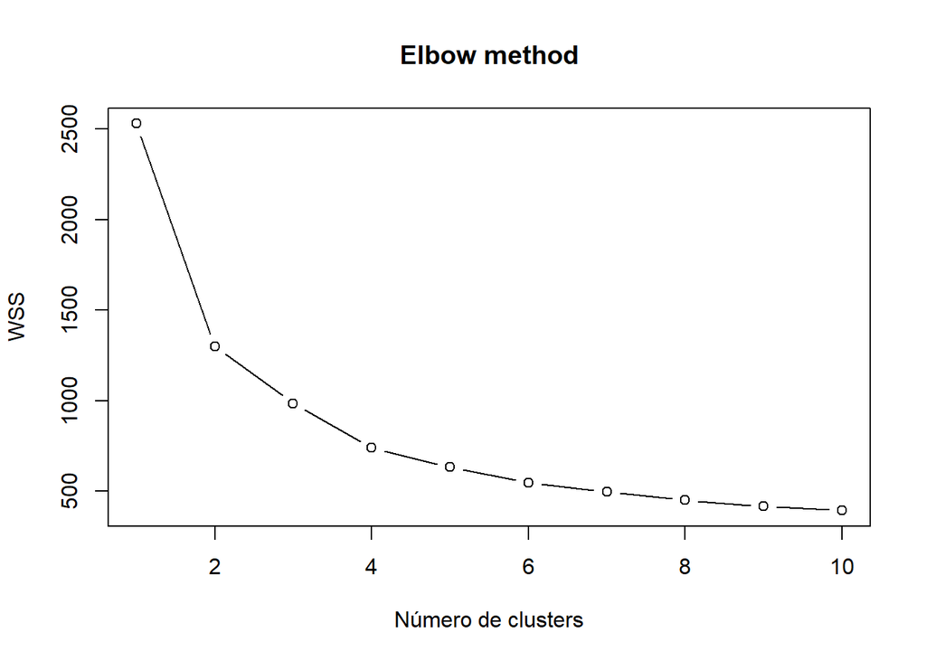

```r
library(ggplot2)
#Variables a usar
varcluster <- BODYDATA[, c("waist_girth","chest_girth","hip_girth","shoulder_girth","thigh_girth")]

#Normalizar los datos
varescaladas <- scale(varcluster)

#ELBOW METHOD. Partimos de 10 clusters.

WSS <- numeric(10)
for(k in 1:10){
  valork <- kmeans(varescaladas, centers = k, nstart = 25)
  WSS[k] <- valork$tot.withinss #suma total WSS
}

plot(1:10, WSS, type="b",
     xlab = "Número de clusters",
     ylab = "WSS",
     main = "Elbow method")
```

La bajada es muy pronunciada hasta el 2, y entre el 2 y el 4 aún vemos una pendiente clara. Esto podría indicarnos que existen dos divisiones evidentes correspondientes a dos agrupaciones de morfologías muy contrarias (cuerpos muy pequeños, y cuerpos muy grandes) y morfologías intermedias que se pueden agrupar dentro de uno o de otro pero que en añadir más divisiones, forman agrupaciones más claras. Haremos el método k-means para 2 y 4 para observar la estructura global (dimorfismo sexual) y una caracterización más detallada de los tipos morfológicos observados en el estudio.

A pesar de entrenar el modelo con varias variables, haremos el plot con waist_girth y hip_girth de manera paralela al estudio descriptivo del inicio del trabajo, para poder compararlo.

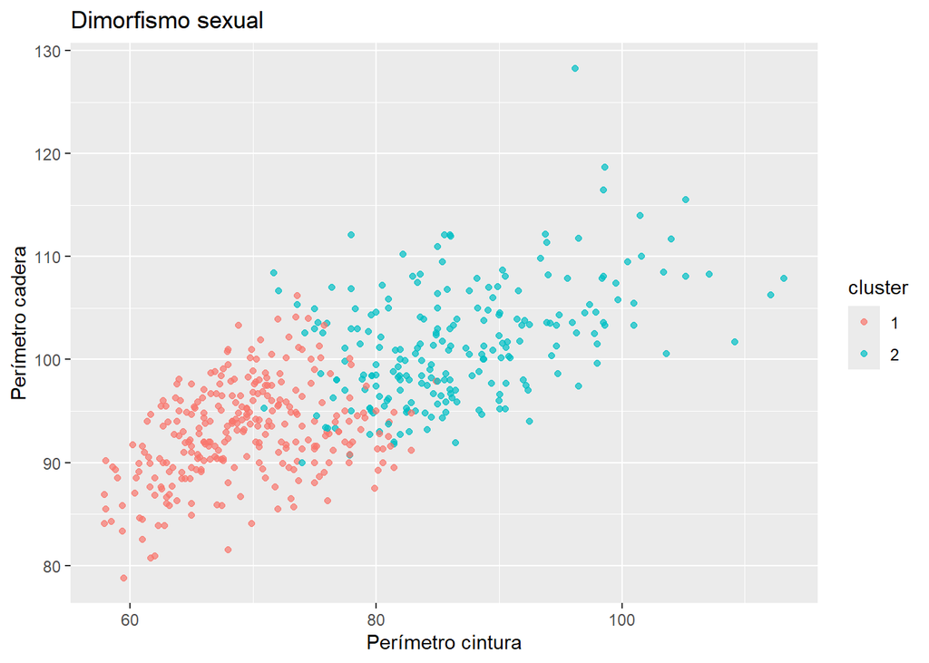

```r
# K-means k=2
set.seed(123)
km <- kmeans(varescaladas, centers = 2, nstart = 25)

#Etiquetamos dataset
BODYDATA$cluster <- factor(km$cluster)
#Plot
ggplot(BODYDATA, aes(x=waist_girth, y=hip_girth, color=cluster)) +
  geom_point(alpha=0.7) +
  labs(title="Dimorfismo sexual",
       x="Perímetro cintura", y="Perímetro cadera")
```

Ahora para 4.

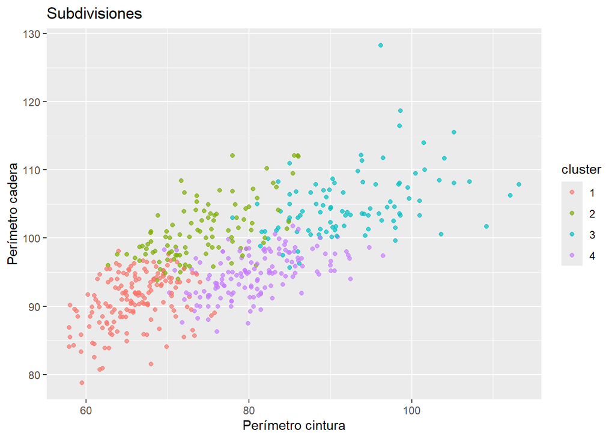

```r
# K-means k=2
set.seed(123)
km <- kmeans(varescaladas, centers = 4, nstart = 25)

#Etiquetamos dataset
BODYDATA$cluster <- factor(km$cluster)
#Plot
ggplot(BODYDATA, aes(x=waist_girth, y=hip_girth, color=cluster)) +
  geom_point(alpha=0.7) +
  labs(title="Subdivisiones",
       x="Perímetro cintura", y="Perímetro cadera")
```

Como podemos ver, en el primer clustering encontramos una división que agrupa parte de datos femeninos en el cluster 2 (de mayoría masculina si tenemos en cuenta el gráfico descriptivo de relación morfológica entre cintura y cadera, figura 3.) y parte de los datos masculinos en el cluster 1 (de mayoría femenina). Esto es porque fenotipos de menor tamaño se asocian en el cluster 1 por tendencia y los demás en el 2.

En añadir la subdivisión (k = 4) podemos ver que se forman 4 grupos que corresponden mucho mejor con la distribución de la figura 3, teniendo en cuenta que cluster 1 y 2 serían de fenotipo femenino, y el cluster 3 y 4 de fenotipo masculino. Los valores atípicos para cada fenotipo se agrupan automáticamente dentro del clúster más cercano y no al que pertenecen realmente ya que el modelo de predicción no tiene tanta precisión como para detectarlos.

Se adjuntan figuras 4 y 5 con marcas para señalar las subdivisiones.

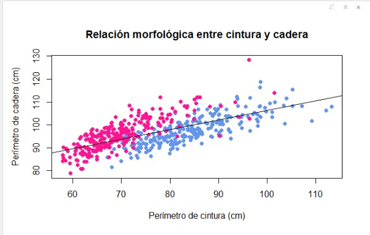

FIGURA 3

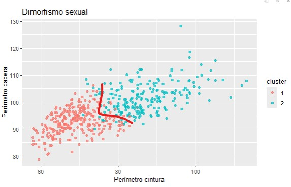

FIGURA 4

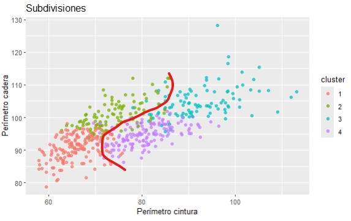

FIGURA 5

##### stepAIC. Aprendizaje supervisado.

Esta parte es simplemente para poder descartar o no medidas más alejadas del core con respaldo estadístico. Este método forma parte del aprendizaje supervisado.

```r
variablesaic <- c(
  "biacromial","biiliac","bitrochanteric",
  "chest_depth","chest_diameter",
  "elbow_diameter","wrist_diameter","knee_diameter","ankle_diameter",
  "shoulder_girth","chest_girth","waist_girth","navel_girth","hip_girth",
  "thigh_girth","bicep_girth","forearm_girth","knee_girth","calf_girth",
  "ankle_girth","wrist_girth"
)

modelfull <- lm(weight ~ ., data = BODYDATA[, c(variablesaic, "weight")])

modelAIC <- step(modelfull, direction = "both", trace = FALSE)
summary(modelAIC)
```

```
##
## Call:
## lm(formula = weight ~ biacromial + biiliac + chest_depth + elbow_diameter +
##     ankle_diameter + shoulder_girth + chest_girth + waist_girth +
##     navel_girth + hip_girth + thigh_girth + forearm_girth + knee_girth +
##     calf_girth, data = BODYDATA[, c(variablesaic, "weight")])
##
## Residuals:
##    Min     1Q Median     3Q    Max
## -8.037 -1.703 -0.015  1.711 12.372
##
## Coefficients:
##                  Estimate Std. Error t value Pr(>|t|)
## (Intercept)    -101.01585    2.58595 -39.063  < 2e-16 ***
## biacromial        0.31521    0.07432   4.241 2.65e-05 ***
## biiliac           0.31398    0.07317   4.291 2.14e-05 ***
## chest_depth       0.35755    0.08626   4.145 4.00e-05 ***
## elbow_diameter    0.72707    0.22178   3.278 0.001118 **
## ankle_diameter    0.54383    0.17543   3.100 0.002046 **
## shoulder_girth    0.13100    0.03805   3.443 0.000625 ***
## chest_girth       0.14492    0.04420   3.279 0.001117 **
## waist_girth       0.30694    0.03103   9.890  < 2e-16 ***
## navel_girth      -0.06203    0.02906  -2.134 0.033313 *
## hip_girth         0.27069    0.05278   5.128 4.21e-07 ***
## thigh_girth       0.25835    0.05952   4.340 1.73e-05 ***
## forearm_girth     0.40001    0.12222   3.273 0.001139 **
## knee_girth        0.52497    0.08915   5.888 7.23e-09 ***
## calf_girth        0.24361    0.07938   3.069 0.002266 **
## ---
## Signif. codes:  0 '***' 0.001 '**' 0.01 '*' 0.05 '.' 0.1 ' ' 1
##
## Residual standard error: 2.688 on 492 degrees of freedom
## Multiple R-squared:  0.9606, Adjusted R-squared:  0.9594
## F-statistic: 855.7 on 14 and 492 DF,  p-value: < 2.2e-16
```

```r
setdiff(variablesaic, names(coef(modelAIC))[-1])
```

```
## [1] "bitrochanteric" "chest_diameter" "wrist_diameter" "knee_diameter"
## [5] "bicep_girth"    "ankle_girth"    "wrist_girth"
```

Por el estadístico F y el p-valor muy inferior al valor crítico podemos determinar que el conjunto de predictores seleccionado es altamente significativo, a pesar de tener un error estandar del 2.69 (aprox.) este es razonable para medidas antropométricas.

Las variables que no mejoran el modelo y se descartaron, muchas son medidas periféricas alejadas del core (ankle, wrist, knee), aunque hay algunas como chest_diameter y bicep_girth que son medidas centrales pero pueden tener mucha variabilidad que no necesariamente se explica por patrones biológicos ni aportan más información a la hora de hacer predicciones. Otra medida, bitrochanteric, que sí se consideró al inicio del estudio como importante fue descartada por no mejorar el modelo.

## Sección 5. Visualización (1,5 puntos)

**Utilizando la herramienta Shiny (basada en los conceptos trabajados en el LAB6), realizad una propuesta de visualización de datos del conjunto de datos trabajado, a partir de unos determinados criterios a vuestra elección.**

Hemos desarrollado una aplicación sencilla Shiny que permite explorar de manera interactiva las relaciones entre distintas medidas corporales del conjunto de datos que hemos llamado “BODYDATA”. La aplicación está dividida en dos pestañas principales, una para el explorador de datos y otra para los gráficos de dispersión con su respectiva regresión lineal.

La pestaña de gráficos permite seleccionar dos variables para enfrentarlas en un gráfico de dispersión. Los puntos aparecen coloreados según el sexo (rosa para mujeres y azul para los hombres igual que en el resto de la PEC para mantener la consistencia) y poder detectar patrones de dimorfismo sexual. Aparece también la recta de regresión lineal de las variables seleccionadas permitiendo así interpretar tendencias.

Los filtros aplicados en la primera pestaña también afectan a los gráficos, así podemos comparar subgrupos específicos y analizar cómo varían estas relaciones antropométricas según estos subgrupos.

```r
library(shiny)
library(shinythemes)
```

```r
#UI

ui <- fluidPage(
  theme = shinytheme("journal"),
  titlePanel("Explorador Body Dimensions"),

  tabsetPanel(
    #Pestaña 1: Explorador
    tabPanel("Explorador de datos",

             sidebarLayout(
               sidebarPanel(
                 #Género
                 checkboxGroupInput(
                   "tablagenero",
                   "Filtro por género",
                   choices = c("Hombres" = 1, "Mujeres" = 0),
                   selected = c(1, 0)
                 ),

                 #Peso
                 sliderInput(
                   "tablapeso",
                   "Rango de peso (en kg)",
                   min = min(BODYDATA$weight, na.rm = TRUE),
                   max = max(BODYDATA$weight, na.rm = TRUE),
                   value = c(min(BODYDATA$weight, na.rm = TRUE), max(BODYDATA$weight, na.rm = TRUE))
                 ),

                 #Edad
                 sliderInput(
                   "tablaedad",
                   "Rango de edad",
                   min = min(BODYDATA$age, na.rm = TRUE),
                   max = max(BODYDATA$age, na.rm = TRUE),
                   value = c(min(BODYDATA$age, na.rm = TRUE), max(BODYDATA$age, na.rm = TRUE))
                 ),

                 #Altura
                 sliderInput(
                   "tablaaltura",
                   "Rango de altura (en cm)",
                   min = min(BODYDATA$height, na.rm = TRUE),
                   max = max(BODYDATA$height, na.rm = TRUE),
                   value = c(min(BODYDATA$height, na.rm = TRUE), max(BODYDATA$height, na.rm = TRUE))
                 ),

                 #Selector de columnas
                 checkboxGroupInput(
                   "columnas",
                   "Filtro de variables:",
                   choices = names(BODYDATA), #Todas las variables
                   selected = names(BODYDATA) #Seleccionadas por defecto
                 )
               ),
               mainPanel(
                 helpText("Nota: Se muestra un máximo de 25 observaciones."),
                 tableOutput("tabla"),
                 helpText("Fuente de los datos: 'Exploring Relationships in Body Dimensions' por Grete Heinz y Louis J. Peterson de la San José State University.")
               )
             )
          ),

    #Pestaña 2: Gráficos
    tabPanel("Gráficos",
             h3("Seleccione las variables"),
             sidebarLayout(
               sidebarPanel(
                 selectInput("xvar", "Variable X", choices = names(BODYDATA), selected = "biacromial"),
                 selectInput("yvar", "Variable Y:", choices = names(BODYDATA), selected = "weight")
               ),
               mainPanel(
                 plotOutput("scatterplot"),
                 verbatimTextOutput("reg_info") #Recta de regresión
               )
             )
    )

  )
)

server <- function(input, output) {

  datos_filtrados <- reactive ({
    BODYDATA[
      BODYDATA$gender %in% input$tablagenero &
      BODYDATA$weight >= input$tablapeso[1] & BODYDATA$weight <= input$tablapeso[2] &
      BODYDATA$age >= input$tablaedad[1] & BODYDATA$age <= input$tablaedad[2] &
      BODYDATA$height >= input$tablaaltura[1] & BODYDATA$height <= input$tablaaltura[2],
    ]
  })

  output$tabla <- renderTable({
    head(datos_filtrados()[, input$columnas, drop = FALSE], 25)
  })

  output$scatterplot <- renderPlot({
    #Datos a usar
    datos <- datos_filtrados()
    x <- datos[[input$xvar]]
    y <- datos[[input$yvar]]
    #Colores gráfico
    grafcolores <- ifelse(datos$gender == 1, "cornflowerblue", "pink")
    #Modelo de regresión lineal:
    modeloreglin <- lm(y ~ x)
    #Hacemos el plot:
    plot(x, y,
         xlab = input$xvar,
         ylab = input$yvar,
         main = paste("Regresión lineal de las variables", input$yvar, "VS", input$xvar),
         pch = 19,
         col = grafcolores)
    #RECTA REGRESIÓN
    abline(modeloreglin, col = "black", lwd = 2)
  })
  output$reg_info <- renderPrint({
    datos <- datos_filtrados()
    x <- datos[[input$xvar]]
    y <- datos[[input$yvar]]
    modeloreglin <- lm(y ~ x)
    coefss <- coef(modeloreglin)
    cat("Recta de regresión:\n")
    cat(paste0("y = ", round(coefss[1], 2), " + ", round(coefss[2], 2), " * x\n"))
    summary(modeloreglin)
  })
}
shinyApp(ui = ui, server = server)
```

Shiny applications not supported in static R Markdown documents

Vista de la aplicación:

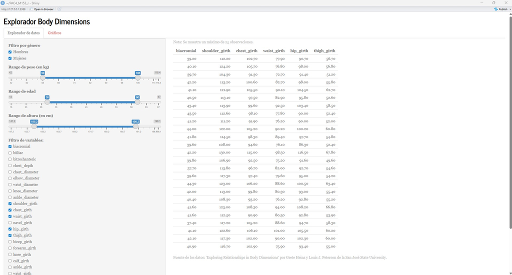

Pestaña 1: Explorador de datos

[figure not shown]

Pestaña 2: Gráficos

## Sección 6. Conclusiones

**A partir de todo el estudio realizado en esta práctica, realizad una valoración final. Para ello, podéis basaros en preguntas como:**

● ¿Disponemos de conclusiones finales? ● ¿Sería necesario realizar un análisis más avanzado? ● ¿Faltan datos para obtener otro tipo de información como…? ● ¿Se puede utilizar alguna de las conclusiones para tomar algún tipo de decisiones? En otro orden de cuestiones, valorad también el trabajo en grupo y la calidad del informe de análisis de datos generado.

### Conclusiones finales.

Con respecto a nuestras preguntas iniciales, acerca del dimorfismo sexual, hemos podido identificar ciertos patrones y diferencias en las medidas antropométricas de hombres y mujeres con respecto al peso. Esto se ve muy bien gracias al visor de gráficos de la aplicación shiny realizada en la sección 5. ###### Relación de la circunferencia de muslo con el peso

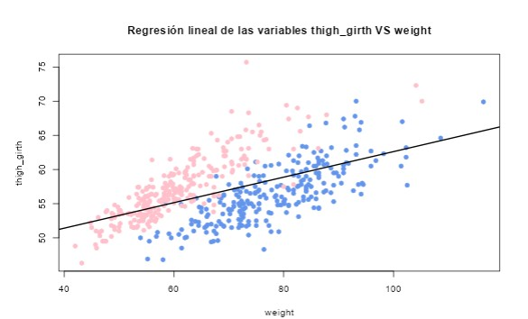

Figura 6

Vemos que para el mismo peso, las mujeres tienden a muslos más anchos. Esto es consistente con los patrones biológicos de acumulación de grasa en las mujeres en el tren inferior (caderas y muslos).

###### Relación de la circunferencia de cadera con el peso

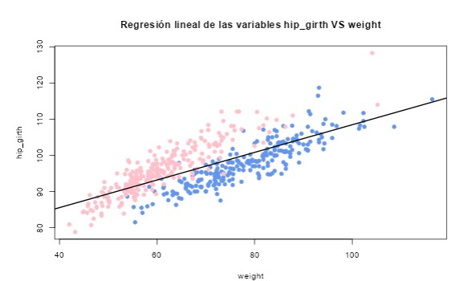

Mismamente, vemos que para el mismo peso, las mujeres tienden a caderas más anchas. De nuevo, consistente con patrones biológicos de acumulación de grasa.

###### Relación de la circunferencia de hombros con el peso

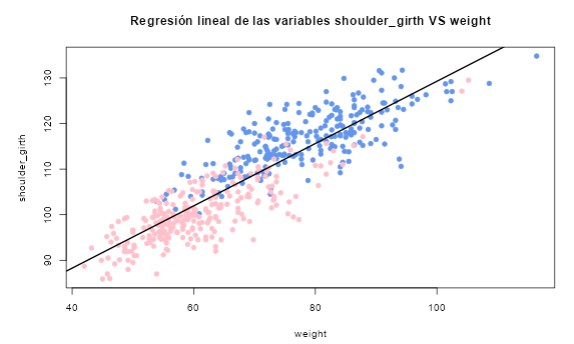

Vemos que de manera global, las mujeres tienden a tener un marco de tren superior inferior en volumen a los hombres alrededor de los hombros, encontrándose que en pesos entre 50 y 80 se encuentran datos de hombres y mujeres pero los hombres presentan mayor volumen que las mujeres. Esto responde al patrón biológico.

###### Relación de la circunferencia de cintura con el peso

Otro ejemplo, encontramos la relación de la circunferencia de cintura con el peso. Encontramos que la cintura parece crecer de manera proporcional con el peso, sin un patrón muy marcado por sexo más que los hombres tienden a presentar más tamaño.

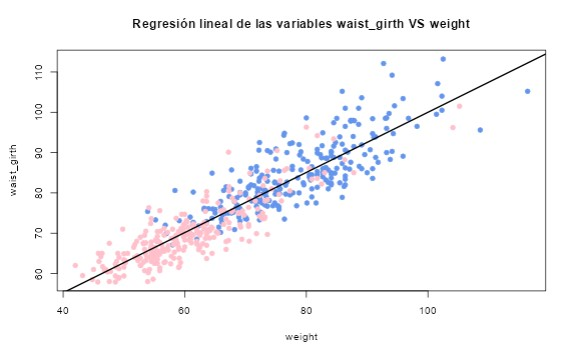

Figura 9

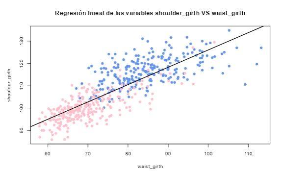

###### Pregunta 2 y Pregunta 3.

Si asumimos que las mujeres favorecen el crecimiento del tren inferior (cadera y muslo) y los hombres favorecen el crecimiento de tren superior (hombros), siendo la cintura un marcador de grasa visceral (no favorecida por ningún patrón sexual en específico), también hemos de asumir que estas distribuciones serán opuestas; es decir, para un mismo valor de cintura, los hombres presentarán mayores hombros que las mujeres, y las mujeres mayor circunferencia de cadera.

Esto podemos verlo en las figuras 3, 5 y 10, y en cómo podemos encontrar estos 4 clusters en todas. El grupo claramente femenino, el grupo claramente masculino, y dos grupos que se encuentran en la misma franja pero uno por encima del otro. Adjuntadas de nuevo aquí:

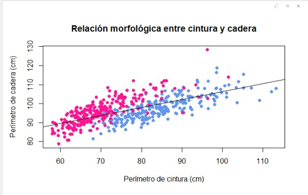

FIGURA 3

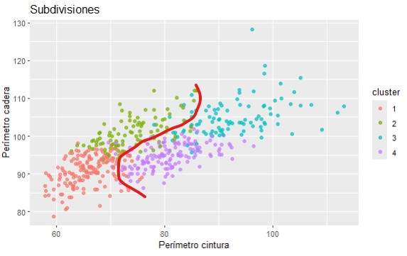

FIGURA 5

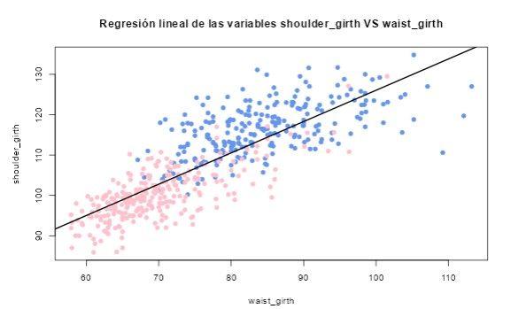

Figura 10

###### Sobre el análisis de clústeres.

El análisis mediante k-means revela agrupamientos morfológicos coherentes cuando se utilizan medidas centrales del cuerpo previamente escaladas. La elección de k=2 permite identificar dos grandes grupos compatibles con dimorfismo sexual, mientras que k=4 ofrece una caracterización más detallada de subtipos corporales dentro de cada sexo. Estos resultados refuerzan la idea de que las medidas del core corporal son determinantes en la diferenciación de perfiles antropométricos.

###### Alcance y limitaciones del estudio.

Aunque los resultados obtenidos son consistentes con patrones biológicos conocidos, deben interpretarse con cautela. El uso de técnicas no supervisadas como k-means permite identificar agrupamientos, pero no establece relaciones causales. Asimismo, la ausencia de medidas directas de composición corporal limita la interpretación del peso y del IMC en términos de grasa corporal frente a masa muscular

En conjunto, este estudio demuestra cómo la combinación de análisis exploratorio, inferencia básica, simulación y aprendizaje automático permite extraer información relevante de datos antropométricos y formular hipótesis coherentes sobre patrones corporales y dimorfismo sexual.

###### ¿Sería necesario realizar un análisis más avanzado?

Sí. Para que los hallazgos sobre proporciones corporales sean estadísticamente significativos deberían explorarse todas las relaciones posibles entre las medidas recogidas en BODYDATA, no sólo los valores individuales o algunos pares. Esto incluiría estudios de correlación entre todos los pares de variables y no sólo los que parecen más lógicos, en este estudio se han priorizado pares como la circunferencia de cintura y la de hombros en pos de otros como la circunferencia de tobillo - ancho biiliaco. También modelos de regresión lineal y múltiple más completos, análisis de interacciones entre medidas centrales y periféricas, y profundizar mucho más con estudios de Análisis de Componentes Principales (PCA) para profundizar en líneas de estudio con más relevancia.

También es importante incorporar un marco teórico previo sobre dimorfismo sexual, patrones biológicos de acumulación de grasa y crecimiento permitiría desarrollar hipótesis más robustas y contextualizadas.

###### ¿Faltan datos para obtener otro tipo de información?

Sí, sería necesario disponer de información adicional para ampliar el alcance de las conclusiones. En particular, medidas directas de composición corporal, como porcentaje de grasa, masa muscular o distribución de grasa visceral, permitirían interpretar de forma más precisa variables como el peso o el índice de masa corporal (IMC). Asimismo, variables relacionadas con hábitos de vida (actividad física, dieta) o factores clínicos enriquecerían el análisis y permitirían contextualizar mejor los patrones antropométricos observados.

###### ¿Se puede utilizar alguna de las conclusiones para tomar algún tipo de decisiones?

Las conclusiones obtenidas pueden servir como base para la toma de decisiones en contextos descriptivos y exploratorios, como estudios poblacionales, diseño ergonómico o análisis antropométricos generales. No obstante, deben interpretarse con cautela y no como criterios clínicos o diagnósticos, ya que el estudio no incluye información médica ni medidas directas de salud. En este sentido, los resultados son útiles para orientar hipótesis o estudios posteriores más específicos.

###### Trabajo y calidad del informe

El trabajo en grupo ha permitido integrar de manera coherente los distintos conceptos trabajados a lo largo de la asignatura, combinando análisis exploratorio, inferencia estadística, simulación, aprendizaje automático y visualización interactiva. La colaboración ha facilitado la división de tareas y la revisión cruzada del código y del contenido, mejorando la claridad y consistencia del informe final. El resultado es un análisis estructurado, reproducible y alineado con los objetivos planteados en la práctica.

###### ¿Se puede utilizar alguna de las conclusiones para tomar algún tipo de decisiones?

Creemos que la conclusión más robusta que hemos sacado de este estudio es que efectivamente en esta muestra existe un dimorfismo sexual y por lo tanto podríamos partir de aquí para hacer estudios en las poblaciones por separado.